# Rmarkdown

2022-10-25

## **Funciones auxiliares**

```r
library(readxl)
library(tidyverse)
```

```r
library(ggplot2)

calculateMean<-function(sheet){
  result <-mean(sheet)
  return(result)
}

calculateStandarDeviation<-function(sheet){
  result <- sd(sheet)
  return(result)
}

calculateZValue<-function(confidenceLevel){
  zValue<- qnorm(c(confidenceLevel),mean=0,sd=1,lower.tail=TRUE)
  return(zValue)
}

calculateStandarError<-function(sd,n){
  standarError <- sd/(sqrt(n))
  return(standarError)
}
```

## **Intervalos de confianza**

*objetivo:* Hallar los intervalos de confianza en duración para 3 géneros.

Para la resolución de este objetivo se selecciona los géneros documentales, películas de terror y acción y aventura, además que se escoge un nivel de confianza del 95%.

$$Estimador \pm (confiabilidad\cdot
error\_estandar)$$

### *Código*

```r
rutaExcel<-file.choose()

ConfidenceIntervalForTheMean<-function(sheet,confidenceLevel){

  n <- length(sheet)
  resultMean <- calculateMean(sheet)
  sd <- calculateStandarDeviation(sheet)
  cl <- confidenceLevel*100
  z <- calculateZValue(confidenceLevel)
  standarError <- calculateStandarError(sd,n)
  limInf <- resultMean-(z*standarError)
  limSup <- resultMean+(z*standarError)

  result <- data.frame(n,resultMean,sd,cl,standarError,limInf,limSup)

  return(result)

}
```

### Documentales

```r
documentaries <- read_excel(rutaExcel,sheet = "d118")
ConfidenceIntervalForTheMean(documentaries$Duration,0.95)
```

```
##     n resultMean       sd cl standarError   limInf   limSup
## 1 118   82.61864 25.37208 95     2.335689 78.77678 86.46051
```

#### análisis

Con un nivel de confianza del 95% y un error estándar del 2.3 % la duración de los documentales del catálogo de películas de Netflix se encuentra entre 78.77 y 86.45 minutos.

### Terror

```r
horrorMovies <- read_excel(rutaExcel,sheet = "hM118")
ConfidenceIntervalForTheMean(horrorMovies$Duration,0.95)
```

```
##     n resultMean       sd cl standarError   limInf   limSup
## 1 118   99.62712 17.65907 95     1.625649 96.95316 102.3011
```

### Acción y aventura

```r
actionAndAdventure <- read_excel(rutaExcel,sheet = "AA118")
ConfidenceIntervalForTheMean(actionAndAdventure$Duration,0.95)
```

```
##     n resultMean       sd cl standarError   limInf   limSup
## 1 118    116.678 25.49975 95     2.347442 112.8168 120.5392
```

## Hipotesis de un grupo

A partir de la gran popularidad que ha adquirido a lo largo de los años Netflix, se asumen que la gran mayoria de sus productos son realmente buenos, es por ello que estos deberían tener una calificación imdbScore alta. Es por ello que Se desea evaluar si el puntaje de las películas del género Documentales del catálogo de Netflix tiene en promedio una aceptación de por lo menos $7.0$; siendo el máximo $10.0$ puntos y el mínimo $1.0$. Con el fin de analizar si al público le gusta el contenido de documentales que ofrece Netflix.

### *Código*

```r
zTestHaLess<-function(sheet,ls,mu){
  n<-length(sheet)
  xbarra<-calculateMean(sheet)
  sd <- calculateStandarDeviation(sheet)
  zcal <- (xbarra-mu)/(sd/sqrt(n))
  zval <- calculateZValue(1-ls)*-1
  result <- data.frame(n,xbarra,sd,ls,zcal,zval)
  return(result)
}
```

Hipotesis del caso para el puntaje medio para una significancia del $5%$:

$H_0$: $μ \geq 7.0$ “Los documentale de Netflix tienen buena aceptación en el publico”

$H_a$: $μ < 7.0$ “Los documentale de Netflix No tienen buena aceptación en el publico”

Rechazo $H_0$ si $Z_{cal} \leq Z_{0.0.5}$

$Z_{cal} \leq Z_{0.05}$

$Z_{cal}= \frac{\bar{x}-μ}{\frac{s}{\sqrt{n}}} \leq Z_{0.05}$

```r
documentariesForH1 <- read_excel(rutaExcel,sheet = "docuH1")
zTestHaLess(documentariesForH1$Score,0.05,7.0)
```

```
##    n   xbarra       sd   ls      zcal      zval
## 1 34 6.708824 0.994033 0.05 -1.708028 -1.644854
```

$$-1.708 \leq -1.644$$
A un nivel de significancia del 5% no hay suficiente evidencia para aceptar $H_0$, por lo tanto, es posible afirmar que en el público de Netflix no tiene buena aceptación hacia el catálogo de documentales de la plataforma.

## Hipótesis de dos grupos

*Objetivo:* Identificar si el puntaje promedio de IMDb de los 2 géneros con mayor contenido son iguales.

Para este caso realizamos una prueba bilateral, en la cual buscamos demostrar que la media de imdb score del género Drama y la media de imdb score del género películas internacionales son diferentes.

**Variables:** $_1 : $ media imdb score peliculas drama $_1 : $ media imdb score peliculas internacionales

**Hipótesis:**

$H_0 : \mu_1 -\mu_2 = 0$ “La media imdb score de las peliculas de drama es igual a la media imdb score de las peliculas internacionales”

$H_a : \mu_1 -\mu_2 \neq 0$ “La media imdb score de las peliculas de drama es diferente a la media imdb score de las peliculas internacionales”

**Resolución:** Utilizamos la herramienta ggplot para verificar si la media del imdb score de los géneros siguen una distribución normal o aproximadamente normal:

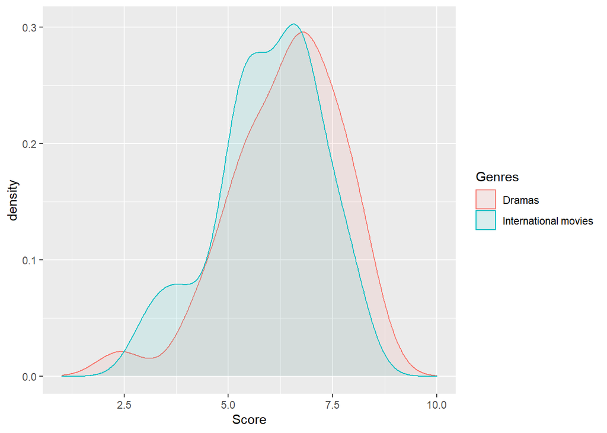

```r
dataFrameH2<- read_excel(rutaExcel,sheet = "pruebasH2")

ggplot(dataFrameH2,aes(Score,fill = Genres, color = Genres))+
  geom_density(alpha=0.1)+
  xlim(1,10)
```

En la gráfica es posible observar que los datos siguen una distribución aproximadamente normal.

Utilizamos la gráfica para hacer una análisis grafico de los valores de la media del imdb score de cada muestra de los géneros de Drama y peliculas internacionales:

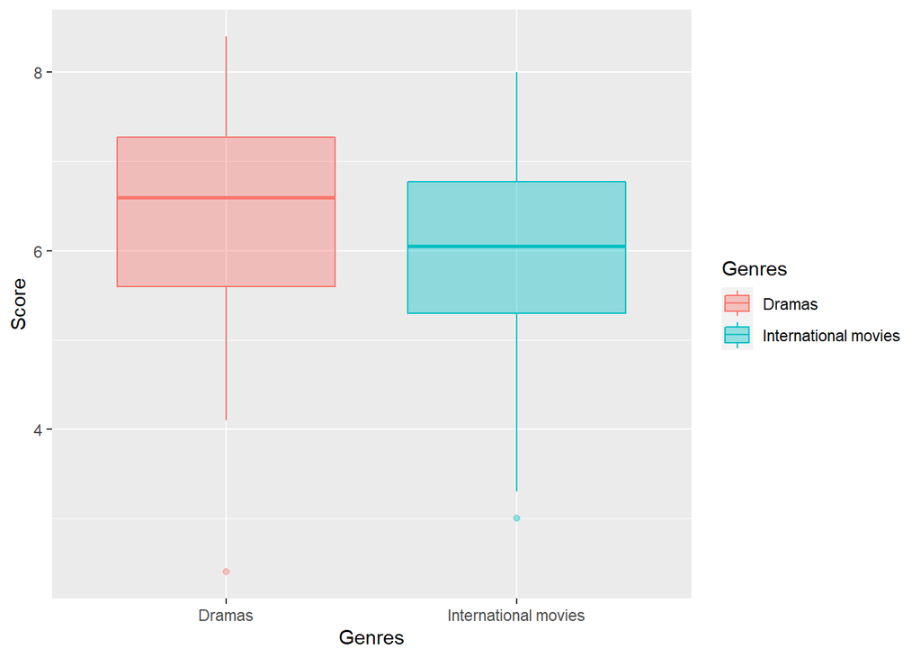

```r
ggplot(dataFrameH2,aes(Genres,Score,fill = Genres, color = Genres))+
  geom_boxplot(alpha=0.4)
```

Determinamos si las varianzas entre los dos grupos son iguales con la pruebas $var.test()$

```r
var.test(Score ~ Genres,data = dataFrameH2)
```

```
##
##  F test to compare two variances
##
## data:  Score by Genres
## F = 1.0731, num df = 33, denom df = 33, p-value = 0.8405
## alternative hypothesis: true ratio of variances is not equal to 1
## 95 percent confidence interval:
##  0.5359539 2.1487547
## sample estimates:
## ratio of variances
##           1.073142
```

Obtenemos un $VrP = 0.8405$ como este valor no es menor al nivel de significancia del 0.05 no rechamos la hipótesis nula. Es decir la varianza entre estos grupos es la misma.

Finalmente realizamos la prueba t de studen asumiendo que las varianza son iguales:

```r
t.test(Score ~ Genres,data = dataFrameH2,var.equal= T)
```

```
##
##  Two Sample t-test
##
## data:  Score by Genres
## t = 1.3011, df = 66, p-value = 0.1978
## alternative hypothesis: true difference in means between group Dramas and group International movies is not equal to 0
## 95 percent confidence interval:
##  -0.2185484  1.0361954
## sample estimates:
##               mean in group Dramas mean in group International movies
##                           6.373529                           5.964706
```

Rechazamos $H_0:sii VrP<0.05$

$0.1978 < 0.05$

Con un nivel de significancia del 5% no hay suficiente evidencia para rechazar $H_0$ por lo cual decimos que las varianzas entre la media imdb score de las películas de drama es igual a la media imdb score de las peliculas internacionales